# Wrangling FIA and Climate Data

Libraries:

```r
library(rFIA)
library(dplyr)
library(ggplot2)
library(rpart)
library(mgcv)
library(tidyr)
library(RNetCDF)
library(tidync)
library(ncmeta)
library(dplyr)
library(ggplot2)
library(tools)
library(sf)
library(maps)
library(patchwork)
```

## Determine top 10 most abundant trees in CO:

Load in Forest data and join `TREE` and `PLOT` tables:

```r
## Object holding loaction of data
COforest <- readFIA("C:/Users/jddru/Desktop/ASAENVR/data/co-fia")

## Plot and Tree tables:
CO.TREE <- COforest$TREE
CO.PLOT <- COforest$PLOT

## Wrangle and Join Tables
CO.tree <- CO.TREE %>% select(
  ## Grab ID and location/plot information...
  CN, PLT_CN, INVYR, ##UNITCD, COUNTYCD, PLOT, SUBP, TREE, CONDID, AZIMUTH, DIST,
  ## Relavent tree measurment...
  STATUSCD, SPCD, DIA, DIAHTCD, HT, HTCD, CR, CCLCD)
  ## Enviromental factors
  ##AGENTCD, CULL, DECAYCD)

CO.plot <- CO.PLOT %>% select(
  ## Grab ID and location information..
  CN, LAT, LON, ELEV
)

## Join the subsets of tables together

CO.forest <- full_join(CO.tree, CO.plot, by = c("PLT_CN" = "CN"))
head(CO.forest)
```

|  | CN | PLT_CN | INVYR | STATUSCD | SPCD | DIA | DIAHTCD | HT | HTCD | CR | CCLCD | LAT | LON | ELEV |
| --- | --- | --- | --- | --- | --- | --- | --- | --- | --- | --- | --- | --- | --- | --- |
| 1 | 3.586563e+12 | 3.586556e+12 | 1984 | 1 | 746 | 1.4 | 1 | 9 | 1 | 75 | 1 | 40.23887 | -105.5378 | 8600 |
| 2 | 3.586564e+12 | 3.586556e+12 | 1984 | 1 | 108 | 8.1 | 1 | 24 | 1 | 55 | 3 | 40.23887 | -105.5378 | 8600 |
| 3 | 3.586565e+12 | 3.586556e+12 | 1984 | 1 | 122 | 13.2 | 1 | 39 | 1 | 75 | 2 | 40.23887 | -105.5378 | 8600 |
| 4 | 3.586566e+12 | 3.586556e+12 | 1984 | 1 | 122 | 7.4 | 1 | 19 | 1 | 65 | 3 | 40.23887 | -105.5378 | 8600 |
| 5 | 3.586567e+12 | 3.586556e+12 | 1984 | 1 | 122 | 9.1 | 1 | 23 | 1 | 65 | 2 | 40.23887 | -105.5378 | 8600 |
| 6 | 3.586568e+12 | 3.586556e+12 | 1984 | 1 | 122 | 1.9 | 1 | 8 | 1 | 65 | 4 | 40.23887 | -105.5378 | 8600 |

Let’s count the number of species of trees in Colorado and see which are the most prevalent:

```r
CO.forest %>% filter(INVYR>=2002 & STATUSCD == 1) %>%
  count(SPCD, sort = TRUE) %>%
  mutate(percent = round(100 * n / sum(n),3))
```

| SPCD | n | percent |
| --- | --- | --- |
| 93 | 33224 | 16.667 |
| 746 | 33150 | 16.630 |
| 108 | 24706 | 12.394 |
| 814 | 20350 | 10.209 |
| 19 | 17664 | 8.861 |
| 65 | 16164 | 8.109 |
| 106 | 15357 | 7.704 |
| 202 | 12882 | 6.462 |
| 122 | 8972 | 4.501 |
| 66 | 3186 | 1.598 |

[output cut: 17 more lines]

```r
spcd.id <- c(746,93,108,814,19,106,65,202,122,18)
CO.forestSub <- CO.forest %>% filter(SPCD %in% spcd.id)
head(CO.forestSub)
```

|  | CN | PLT_CN | INVYR | STATUSCD | SPCD | DIA | DIAHTCD | HT | HTCD | CR | CCLCD | LAT | LON | ELEV |
| --- | --- | --- | --- | --- | --- | --- | --- | --- | --- | --- | --- | --- | --- | --- |
| 1 | 3.586563e+12 | 3.586556e+12 | 1984 | 1 | 746 | 1.4 | 1 | 9 | 1 | 75 | 1 | 40.23887 | -105.5378 | 8600 |
| 2 | 3.586564e+12 | 3.586556e+12 | 1984 | 1 | 108 | 8.1 | 1 | 24 | 1 | 55 | 3 | 40.23887 | -105.5378 | 8600 |
| 3 | 3.586565e+12 | 3.586556e+12 | 1984 | 1 | 122 | 13.2 | 1 | 39 | 1 | 75 | 2 | 40.23887 | -105.5378 | 8600 |
| 4 | 3.586566e+12 | 3.586556e+12 | 1984 | 1 | 122 | 7.4 | 1 | 19 | 1 | 65 | 3 | 40.23887 | -105.5378 | 8600 |
| 5 | 3.586567e+12 | 3.586556e+12 | 1984 | 1 | 122 | 9.1 | 1 | 23 | 1 | 65 | 2 | 40.23887 | -105.5378 | 8600 |
| 6 | 3.586568e+12 | 3.586556e+12 | 1984 | 1 | 122 | 1.9 | 1 | 8 | 1 | 65 | 4 | 40.23887 | -105.5378 | 8600 |

Get plot ID for live trees (`STATUSCD` = 1) from 2002 and beyond:

```r
#CO.TreeBin <- CO.forestSub %>%
  # mutate(value = 1) %>%
  # pivot_wider(names_from = SPCD,
  #             values_from = value,
  #             values_fill = list(value = 0),
  #             names_prefix = "SPCD") %>%
  ##mutate(value = 1) %>% spread(key = SPCD, value, fill = 0) %>%
  #filter(INVYR >= 2002 & STATUSCD == 1) %>%
  #select(-c(CN))

CO.TreeBin <- CO.forestSub %>%
  filter(INVYR >= 2002 & STATUSCD == 1) %>%
  select(PLT_CN, INVYR, LAT, LON, ELEV, SPCD) %>%
  mutate(SPCD = factor(SPCD)) %>%
  group_by(PLT_CN, LAT, LON, ELEV, SPCD) %>%
  summarise(species_count =  n()) %>%
  pivot_wider(names_from = SPCD,
              values_from = species_count,
              values_fill = list(species_count = 0),
              names_prefix = 'SPCD_') %>%
  ungroup()
head(CO.TreeBin)
```

| PLT_CN | LAT | LON | ELEV | SPCD_202 | SPCD_746 | SPCD_122 | SPCD_814 | SPCD_19 | SPCD_93 | SPCD_65 | SPCD_106 | SPCD_108 | SPCD_18 |
| --- | --- | --- | --- | --- | --- | --- | --- | --- | --- | --- | --- | --- | --- |
| 3.641686e+12 | 37.29803 | -107.3133 | 8050 | 9 | 17 | 0 | 0 | 0 | 0 | 0 | 0 | 0 | 0 |
| 3.641756e+12 | 37.20763 | -107.4224 | 8090 | 8 | 0 | 4 | 14 | 0 | 0 | 0 | 0 | 0 | 0 |
| 3.641817e+12 | 37.02951 | -106.9084 | 7160 | 9 | 0 | 16 | 19 | 0 | 0 | 0 | 0 | 0 | 0 |
| 3.641972e+12 | 37.32485 | -106.8509 | 9990 | 0 | 0 | 0 | 0 | 17 | 1 | 0 | 0 | 0 | 0 |
| 3.642016e+12 | 36.99328 | -106.8636 | 8110 | 0 | 0 | 11 | 0 | 0 | 0 | 0 | 0 | 0 | 0 |
| 3.642035e+12 | 37.02996 | -107.1870 | 6800 | 0 | 0 | 0 | 1 | 0 | 0 | 2 | 5 | 0 | 0 |

Plot locations with no observations:

```r
no.obs <- CO.forest %>% filter((CN %in% CO.TreeBin$PLT_CN) == FALSE &
                                 is.na(INVYR) == TRUE)
```

## Soils data

Read into R:

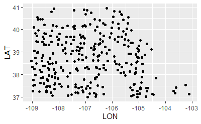

```r
soil.lab <- read.csv("C:/Users/jddru/Desktop/ASAENVR/data/co-fia/CO_SOILS_LAB.csv", header = TRUE)
soil.loc <- read.csv("C:/Users/jddru/Desktop/ASAENVR/data/co-fia/CO_SOILS_SAMPLE_LOC.csv", header = TRUE)

soil.lab.summary <- soil.lab %>%
  group_by(CN, PLT_CN, STATECD, COUNTYCD, PLOT) %>%
  summarise_at(vars(FIELD_MOIST_SOIL_WT:OLSEN_P), mean)


soil.geo <- inner_join(CO.TreeBin, soil.lab.summary)
ggplot(soil.geo, aes(x = LON, y = LAT)) +
  geom_point()
```

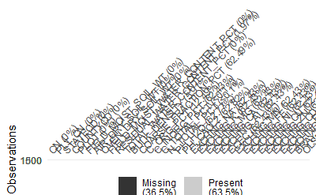

```r
naniar::vis_miss(soil.lab.summary, warn_large_data = FALSE)
```

Remove the mineral measurements due the missing data.

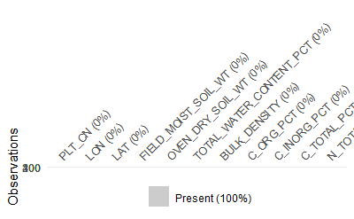

```r
soil.geo.sub <- soil.geo %>%
  select(PLT_CN, LON, LAT, FIELD_MOIST_SOIL_WT, OVEN_DRY_SOIL_WT, TOTAL_WATER_CONTENT_PCT,
         BULK_DENSITY, C_ORG_PCT, C_INORG_PCT, C_TOTAL_PCT, N_TOTAL_PCT) %>%
  mutate(C_INORG_PCT = C_TOTAL_PCT-C_ORG_PCT) %>%
  na.omit() %>%
  group_by(PLT_CN, LON, LAT) %>%
  summarise_all(mean)


naniar::vis_miss(soil.geo.sub, warn_large_data = FALSE)
```

Get the texture measurements at the locations:

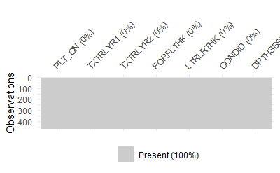

```r
## Select appropriate columns
soil.loc.sub <- soil.loc %>%
  filter(SOILS_STATCD == 1) %>%
  select(PLT_CN, FORFLTHK, LTRLRTHK, CONDID, TXTRLYR1, TXTRLYR2, DPTHSBSL) %>%
  mutate(DPTHSBSL = replace(DPTHSBSL, DPTHSBSL==99.9,0)) %>%
  na.omit() %>%
  group_by(PLT_CN,TXTRLYR1,TXTRLYR2) %>%
  summarise_all(mean) %>%
  mutate(TXTRLYR1 = factor(TXTRLYR1),
         TXTRLYR2 = factor(TXTRLYR2))


naniar::vis_miss(soil.loc.sub, warn_large_data = FALSE)
```

Join:

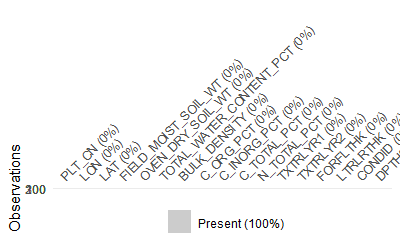

```r
soils.df <- inner_join(soil.geo.sub,soil.loc.sub)
naniar::vis_miss(soils.df, warn_large_data = FALSE)
```

Look at the summary of the combined soils data:

```r
summary(soils.df)
```

```
     PLT_CN               LON              LAT        FIELD_MOIST_SOIL_WT OVEN_DRY_SOIL_WT TOTAL_WATER_CONTENT_PCT  BULK_DENSITY
 Min.   :3.643e+12   Min.   :-109.0   Min.   :37.00   Min.   :   3.47     Min.   :  3.36   Min.   :  1.058         Min.   :0.0240
 1st Qu.:1.221e+13   1st Qu.:-108.2   1st Qu.:37.76   1st Qu.: 168.37     1st Qu.:145.50   1st Qu.:  7.257         1st Qu.:0.3716
 Median :3.167e+13   Median :-107.0   Median :38.62   Median : 249.48     Median :208.86   Median : 15.818         Median :0.5728
 Mean   :5.242e+13   Mean   :-106.9   Mean   :38.69   Mean   : 317.93     Mean   :238.22   Mean   : 26.088         Mean   :0.6390
 3rd Qu.:3.727e+13   3rd Qu.:-105.8   3rd Qu.:39.51   3rd Qu.: 380.62     3rd Qu.:296.13   3rd Qu.: 34.542         3rd Qu.:0.8009
 Max.   :1.888e+14   Max.   :-103.1   Max.   :40.95   Max.   :1502.29     Max.   :867.07   Max.   :199.553         Max.   :3.1482
   C_ORG_PCT        C_INORG_PCT       C_TOTAL_PCT      N_TOTAL_PCT     TXTRLYR1 TXTRLYR2    FORFLTHK        LTRLRTHK
 Min.   : 0.3085   Min.   :0.00000   Min.   : 0.546   Min.   :0.0305   3: 52    3: 54    Min.   :0.000   Min.   :0.0000
 1st Qu.:11.4458   1st Qu.:0.03188   1st Qu.:11.588   1st Qu.:0.3872   1:208    1:156    1st Qu.:0.175   1st Qu.:0.1500
 Median :18.7541   Median :0.08430   Median :18.894   Median :0.6088   2: 56    9: 34    Median :0.650   Median :0.4000
 Mean   :18.5276   Mean   :0.19830   Mean   :18.726   Mean   :0.6045   9: 13    4: 12    Mean   :1.033   Mean   :0.5512
 3rd Qu.:24.8564   3rd Qu.:0.14216   3rd Qu.:24.987   3rd Qu.:0.8033   0:  7    2: 87    3rd Qu.:1.650   3rd Qu.:0.8250
 Max.   :47.2243   Max.   :4.36800   Max.   :47.224   Max.   :1.7413   4: 10    0:  3    Max.   :6.275   Max.   :2.3750
     CONDID         DPTHSBSL
 Min.   :1.000   Min.   : 0.000
 1st Qu.:1.000   1st Qu.: 2.000
 Median :1.000   Median : 4.200
 Mean   :1.066   Mean   : 5.472
 3rd Qu.:1.000   3rd Qu.: 7.175
 Max.   :3.000   Max.   :20.000
```

Plot the soil locations in black, and the tree plot locations in red:

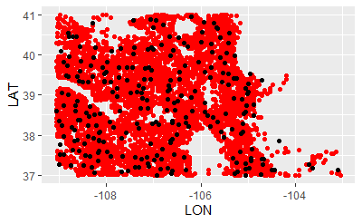

```r
ggplot(data = CO.TreeBin, aes(x = LON, y = LAT)) +
  geom_point(color = "red") +
  geom_point(data = soils.df, aes(x = LON, y = LAT))
```

Interpolate the soil data with KNN k=1 interpolation. Based on the latitude and longitude coordinates of a tree plot location, we will find the nearest soil plot and obtain the plot ID:

```r
tree.locs <- data.frame(CO.TreeBin %>% select(c(PLT_CN,LON,LAT)))
tree.locs <- tree.locs[,2:3]
soil.locs <- soils.df %>% select(c(PLT_CN,LON,LAT)) %>% as.data.frame()
soil.coords <- soil.locs[,2:3]
soil.cs <- factor(soil.locs[,1])

soil.interp <- class::knn(soil.coords,
                          tree.locs,
                          soil.cs,
                          k = 1)
```

Add soil plot column:

```r
CO.TreeBin$SOIL_PLT_CN = as.numeric(as.character(soil.interp))

head(CO.TreeBin)
```

| PLT_CN | LAT | LON | ELEV | SPCD_202 | SPCD_746 | SPCD_122 | SPCD_814 | SPCD_19 | SPCD_93 | SPCD_65 | SPCD_106 | SPCD_108 | SPCD_18 | SOIL_PLT_CN |
| --- | --- | --- | --- | --- | --- | --- | --- | --- | --- | --- | --- | --- | --- | --- |
| 3.641686e+12 | 37.29803 | -107.3133 | 8050 | 9 | 17 | 0 | 0 | 0 | 0 | 0 | 0 | 0 | 0 | 1.887605e+14 |
| 3.641756e+12 | 37.20763 | -107.4224 | 8090 | 8 | 0 | 4 | 14 | 0 | 0 | 0 | 0 | 0 | 0 | 3.166027e+13 |
| 3.641817e+12 | 37.02951 | -106.9084 | 7160 | 9 | 0 | 16 | 19 | 0 | 0 | 0 | 0 | 0 | 0 | 3.166040e+13 |
| 3.641972e+12 | 37.32485 | -106.8509 | 9990 | 0 | 0 | 0 | 0 | 17 | 1 | 0 | 0 | 0 | 0 | 3.166928e+13 |
| 3.642016e+12 | 36.99328 | -106.8636 | 8110 | 0 | 0 | 11 | 0 | 0 | 0 | 0 | 0 | 0 | 0 | 3.166040e+13 |
| 3.642035e+12 | 37.02996 | -107.1870 | 6800 | 0 | 0 | 0 | 1 | 0 | 0 | 2 | 5 | 0 | 0 | 1.887578e+14 |

Join soil data by soil plot ID:

```r
CO.TreeBinSoil <- inner_join(CO.TreeBin, soils.df, by = c("SOIL_PLT_CN" = "PLT_CN")) %>%
  select(-c(LON.y, LAT.y)) %>%
  rename(LAT = LAT.x, LON = LON.x)

head(CO.TreeBinSoil)
```

| PLT_CN | LAT | LON | ELEV | SPCD_202 | SPCD_746 | SPCD_122 | SPCD_814 | SPCD_19 | SPCD_93 | SPCD_65 | SPCD_106 | SPCD_108 | SPCD_18 | SOIL_PLT_CN | FIELD_MOIST_SOIL_WT | OVEN_DRY_SOIL_WT | TOTAL_WATER_CONTENT_PCT | BULK_DENSITY | C_ORG_PCT | C_INORG_PCT | C_TOTAL_PCT | N_TOTAL_PCT | TXTRLYR1 | TXTRLYR2 | FORFLTHK | LTRLRTHK | CONDID | DPTHSBSL |
| --- | --- | --- | --- | --- | --- | --- | --- | --- | --- | --- | --- | --- | --- | --- | --- | --- | --- | --- | --- | --- | --- | --- | --- | --- | --- | --- | --- | --- |
| 3.641686e+12 | 37.29803 | -107.3133 | 8050 | 9 | 17 | 0 | 0 | 0 | 0 | 0 | 0 | 0 | 0 | 1.887605e+14 | 322.940 | 287.435 | 12.650 | 1.5880 | 1.6595 | 0.0630 | 1.7225 | 0.1270 | 2 | 2 | 1.725 | 1.300 | 1 | 8.3 |
| 3.641756e+12 | 37.20763 | -107.4224 | 8090 | 8 | 0 | 4 | 14 | 0 | 0 | 0 | 0 | 0 | 0 | 3.166027e+13 | 240.566 | 212.598 | 12.198 | 0.5824 | 23.5020 | 0.1104 | 23.6124 | 0.7338 | 1 | 1 | 0.775 | 0.650 | 1 | 1.3 |
| 3.641817e+12 | 37.02951 | -106.9084 | 7160 | 9 | 0 | 16 | 19 | 0 | 0 | 0 | 0 | 0 | 0 | 3.166040e+13 | 165.486 | 147.742 | 9.238 | 0.6402 | 11.8436 | 0.0742 | 11.9178 | 0.4278 | 2 | 2 | 1.225 | 1.225 | 1 | 4.6 |
| 3.641972e+12 | 37.32485 | -106.8509 | 9990 | 0 | 0 | 0 | 0 | 17 | 1 | 0 | 0 | 0 | 0 | 3.166928e+13 | 259.174 | 211.430 | 20.600 | 0.4212 | 27.5080 | 0.1156 | 27.6236 | 1.0492 | 1 | 1 | 1.300 | 0.650 | 1 | 4.1 |
| 3.642016e+12 | 36.99328 | -106.8636 | 8110 | 0 | 0 | 11 | 0 | 0 | 0 | 0 | 0 | 0 | 0 | 3.166040e+13 | 165.486 | 147.742 | 9.238 | 0.6402 | 11.8436 | 0.0742 | 11.9178 | 0.4278 | 2 | 2 | 1.225 | 1.225 | 1 | 4.6 |
| 3.642035e+12 | 37.02996 | -107.1870 | 6800 | 0 | 0 | 0 | 1 | 0 | 0 | 2 | 5 | 0 | 0 | 1.887578e+14 | 245.245 | 211.245 | 16.400 | 1.1670 | 4.3350 | 4.3680 | 8.7030 | 0.3385 | 1 | 1 | 2.075 | 1.350 | 1 | 8.0 |

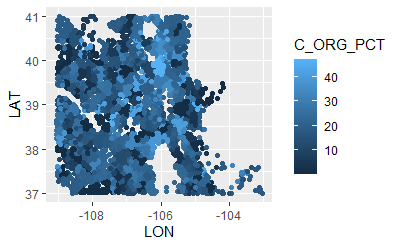

```r
ggplot(data = CO.TreeBinSoil, aes(x = LON, y = LAT, color = C_ORG_PCT)) +
  geom_point()
```

## Climate Data

Set file paths do data:

```r
file.maxt <- "C:/Users/jddru/Desktop/ASAENVR/data/era-interim/MAXT.nc" # Maximum temperature
file.mint <- "C:/Users/jddru/Desktop/ASAENVR/data/era-interim/MINT.nc" # Minimum temperature
file.prec <- "C:/Users/jddru/Desktop/ASAENVR/data/era-interim/PREC.nc" # Precipitation

##source('C:/Users/jddru/Desktop/ASAENVR/Colorado_Forests/load_netcdf.R')
```

Functions to get the data from the netCDF file:

```r
## function to get the data

getCDF.data <- function(filePath, lonRange, latRange, timeRange){

  ## values for selecting a lat/long range and a time

  vals <- t(data.frame(lon = lonRange,
                    lat = latRange,
                    tim = timeRange,
                    row.names = c("min", "max")))

  ## Load the file

  df.out <- tidync(filePath)

  ## Get subset based on lon/lat and time specifications, return what's below

  df.out %>% hyper_filter(lon = between(lon, vals["lon", "min"], vals["lon", "max"]),
                          lat = between(lat, vals["lat", "min"], vals["lat", "max"]),
                           time = between(time, vals["tim", "min"], vals["tim", "max"])) %>%
    hyper_tibble()

}

## function to get the times

ParseNetCDFTime <- function(variableMetadata, variableData) {

  ## get the time units from metatdata
  time.unit <- nc_atts(variableMetadata, "time") %>%
    unnest(cols = c(value)) %>%
    filter(name == "units")

  ## get the time parts and return what's below
  time.parts <- utcal.nc(time.unit$value, variableData$time)
  ISOdatetime(time.parts[, "year"],
              time.parts[, "month"],
              time.parts[, "day"],
              time.parts[, "hour"],
              time.parts[, "minute"],
              time.parts[, "second"],
              tz = "UTC")
}
```

We need to get human-usable times for aggregation and filtering, this needs to be done in a slightly round-about-way to avoid memory issues. (Thus far, I haven’t thought of a more elegant way of doing this with our current NETCDF infrastructure.) First let’s grab a time series at a location in order to get a mapping from the date index to an actual date:

```r
## Grab series
era.ts <- getCDF.data(filePath = file.maxt,
                       lonRange = c(255,255),
                       latRange = c(40.5,40.5),
                       timeRange = c(0,14245))

## Convert the time index to date and drop unnecessary cols
era.ts <- era.ts %>%
  mutate(date = ParseNetCDFTime(file.maxt, era.ts)) %>%
  select(-(MAXT)) %>%
  select(-(lon)) %>%
  select(-(lat))

## Parse the date to year, month, date for filtering/aggregation
era.ts <- era.ts %>% mutate(year = lubridate::year(date),
                            month = lubridate::month(date),
                            day = lubridate::day(date))
head(era.ts)
```

| time | date | year | month | day |
| --- | --- | --- | --- | --- |
| 0 | 1979-01-01 | 1979 | 1 | 1 |
| 1 | 1979-01-02 | 1979 | 1 | 2 |
| 2 | 1979-01-03 | 1979 | 1 | 3 |
| 3 | 1979-01-04 | 1979 | 1 | 4 |
| 4 | 1979-01-05 | 1979 | 1 | 5 |
| 5 | 1979-01-06 | 1979 | 1 | 6 |

```r
t.start <- as.numeric(era.ts %>% filter(year == 1979, month == 1, day == 1) %>%
                        select(time))
t.end <- max(era.ts$time)

lat.max <- 45
lat.min <- 33

lon.max <- 262.5
lon.min <- 247.75
```

Now let’s grab the subset of the ERA-Interim climate data:

```r
maxt.df <- getCDF.data(filePath = file.maxt,
                       lonRange = c(lon.min,lon.max),
                       latRange = c(lat.min,lat.max),
                       timeRange = c(t.start,t.end))
mint.df <- getCDF.data(filePath = file.mint,
                       lonRange = c(lon.min,lon.max),
                       latRange = c(lat.min,lat.max),
                       timeRange = c(t.start,t.end))
prec.df <- getCDF.data(filePath = file.prec,
                       lonRange = c(lon.min,lon.max),
                       latRange = c(lat.min,lat.max),
                       timeRange = c(t.start,t.end))
```

Now, let’s join the date table to each of these so we can aggregate/filter:

```r
maxt.df <- inner_join(maxt.df, era.ts, by = "time")
mint.df <- inner_join(mint.df, era.ts, by = "time")
prec.df <- inner_join(prec.df, era.ts, by = "time")

climate.df <- left_join(maxt.df, mint.df) %>%
  left_join(., prec.df) %>%
  mutate(date = ParseNetCDFTime(file.maxt, maxt.df)) %>%
  mutate(year = lubridate::year(date),
         month = lubridate::month(date),
         day = lubridate::day(date)) %>%
  select(lon, lat, MAXT, MINT, PREC, year, month, day)
head(climate.df)
```

| lon | lat | MAXT | MINT | PREC | year | month | day |
| --- | --- | --- | --- | --- | --- | --- | --- |
| 248.25 | 33 | 283.2372 | 273.3612 | 0.0000000000 | 1979 | 1 | 1 |
| 249.00 | 33 | 281.2246 | 271.7533 | 0.0000000000 | 1979 | 1 | 1 |
| 249.75 | 33 | 278.5472 | 269.7189 | 0.0002653897 | 1979 | 1 | 1 |
| 250.50 | 33 | 276.6946 | 269.6148 | 0.0003855824 | 1979 | 1 | 1 |
| 251.25 | 33 | 275.5560 | 268.9741 | 0.0002253354 | 1979 | 1 | 1 |
| 252.00 | 33 | 275.5683 | 266.8152 | 0.0000000000 | 1979 | 1 | 1 |

Let’s obtain the following explanatory variables:

Main climate variables:

```r
## Average temperature
temp.avg <- climate.df %>%
  group_by(lon, lat) %>%
  summarise(AVGT = mean((MAXT + MINT)/ 2 ))
## Average January/February temperature
temp.janAvg <- climate.df %>%
  filter(month %in% c(1,2)) %>%
  group_by(lon, lat) %>%
  summarise(JANT = mean((MAXT + MINT)/2))
## Average July/August temperature
temp.julyAvg <- climate.df %>%
  filter(month %in% c(7,8)) %>%
  group_by(lon, lat) %>%
  summarise(JULT = mean((MAXT + MINT)/2))
## Variation in mean summer temperature
temp.varS <- climate.df %>%
  filter(month %in% c(6,7,8)) %>%
  group_by(lon,lat) %>%
  summarise(VARS = var((MAXT + MINT)/2))
## Variation in winter mean temperature
temp.varW <- climate.df %>%
  filter(month %in% c(1,2,12)) %>%
  group_by(lon,lat) %>%
  summarise(VARW = var((MAXT + MINT)/2))
## Variation in annual mean temperature
temp.varA <- climate.df %>%
  group_by(lon,lat) %>%
  summarise(VARA = var((MAXT + MINT)/2))
## Difference in summer high and low temperature
temp.diffS <- climate.df %>%
  filter(month %in% c(6,7,8)) %>%
  group_by(lon,lat) %>%
  summarise(DIFS = mean(MAXT - MINT))
## Difference in winter high and low temperature
temp.diffW <- climate.df %>%
  filter(month %in% c(1,2,12)) %>%
  group_by(lon,lat) %>%
  summarise(DIFW = mean(MAXT - MINT))
## Annual cumulative precipitation
temp.precAvg <- climate.df %>%
  group_by(lon,lat) %>%
  summarise(PPT = sum(PREC))
## Summer cumulative precipitation
temp.precS <- climate.df %>%
  filter(month %in% c(6,7,8)) %>%
  group_by(lon,lat) %>%
  summarise(PPTS = sum(PREC))
## Winter cumulative precipitation
temp.precW <- climate.df %>%
  filter(month %in% c(1,2,12)) %>%
  group_by(lon,lat) %>%
  summarise(PPTW = sum(PREC))
## Annual precipitation variation
temp.precvar <- climate.df %>%
  group_by(lon,lat) %>%
  summarise(VARP = var(PREC))
climateSummary.df <- left_join(temp.avg,temp.janAvg) %>%
  left_join(.,temp.julyAvg) %>%
  left_join(., temp.precAvg) %>%
  left_join(., temp.varS) %>%
  left_join(., temp.varW) %>%
  left_join(., temp.varA) %>%
  left_join(., temp.diffS) %>%
  left_join(., temp.diffW) %>%
  left_join(., temp.varW) %>%
  left_join(., temp.precAvg) %>%
  left_join(., temp.precS) %>%
  left_join(., temp.precW) %>%
  left_join(., temp.precvar)
remove(temp.avg, temp.janAvg, temp.julyAvg, temp.precAvg, temp.highvar, temp.lowvar, temp.precvar)
```

```
object 'temp.highvar' not foundobject 'temp.lowvar' not found
```

```r
head(climateSummary.df)
```

| lon | lat | AVGT | JANT | JULT | PPT | VARS | VARW | VARA | DIFS | DIFW | PPTS | PPTW | VARP |
| --- | --- | --- | --- | --- | --- | --- | --- | --- | --- | --- | --- | --- | --- |
| 248.25 | 33.00 | 294.8818 | 285.2078 | 305.1626 | 14.15787 | 8.037292 | 11.50828 | 70.55263 | 13.15480 | 13.02437 | 2.873224 | 5.619463 | 1.528995e-05 |
| 248.25 | 33.75 | 292.3225 | 282.6876 | 302.8348 | 17.08023 | 7.889008 | 10.77423 | 71.01381 | 13.23214 | 12.69083 | 2.843465 | 7.292071 | 2.186447e-05 |
| 248.25 | 34.50 | 287.8049 | 278.4724 | 298.1628 | 20.44307 | 7.563957 | 10.86004 | 67.84694 | 13.70407 | 12.17940 | 3.945709 | 7.792776 | 2.315443e-05 |
| 248.25 | 35.25 | 285.2126 | 275.4434 | 295.9397 | 18.02625 | 7.523313 | 12.82782 | 72.54213 | 14.33213 | 11.93685 | 4.205830 | 5.766044 | 1.345133e-05 |
| 248.25 | 36.00 | 285.3090 | 274.7742 | 296.7857 | 14.91625 | 8.016598 | 14.06787 | 82.54474 | 14.47228 | 11.69296 | 3.494308 | 4.382995 | 8.816046e-06 |
| 248.25 | 36.75 | 285.8646 | 274.5720 | 298.2043 | 12.99955 | 8.746758 | 15.03778 | 93.57732 | 13.67582 | 11.05416 | 2.499485 | 3.911661 | 7.333569e-06 |

Fit GAM models to smooth each of the variables for interpolation/prediction:

```r
gam.avgt <- gam(AVGT ~ s(lon) + s(lat) + ti(lon, lat), method = 'REML', data = climateSummary.df)
gam.jant <- gam(JANT ~ s(lon) + s(lat) + ti(lon, lat), method = 'REML',data = climateSummary.df)
gam.jult <- gam(JULT ~ s(lon) + s(lat) + ti(lon, lat), method = 'REML', data = climateSummary.df)
gam.ppt  <- gam(PPT  ~ s(lon) + s(lat) + ti(lon, lat), method = 'REML', data = climateSummary.df)
gam.vars <- gam(VARS ~ s(lon) + s(lat) + ti(lon, lat), method = 'REML', data = climateSummary.df)
gam.varw <- gam(VARW ~ s(lon) + s(lat) + ti(lon, lat), method = 'REML', data = climateSummary.df)
gam.vara <- gam(VARA ~ s(lon) + s(lat) + ti(lon, lat), method = 'REML', data = climateSummary.df)
gam.difs <- gam(DIFS ~ s(lon) + s(lat) + ti(lon, lat), method = 'REML', data = climateSummary.df)
gam.difw <- gam(DIFW ~ s(lon) + s(lat) + ti(lon, lat), method = 'REML', data = climateSummary.df)
gam.ppts <- gam(PPTS ~ s(lon) + s(lat) + ti(lon, lat), method = 'REML', data = climateSummary.df)
gam.pptw <- gam(PPTW ~ s(lon) + s(lat) + ti(lon, lat), method = 'REML',data = climateSummary.df)
gam.varp <- gam(VARP ~ s(lon) + s(lat) + ti(lon, lat), method = 'REML', data = climateSummary.df)
```

Look at difference in summer temperature:

```r
par(mfrow = c(1,3))
plot.gam(gam.difs, select = 1, residuals = TRUE, xlab = 'Longitude')
plot.gam(gam.difs, select = 2, residuals = TRUE, xlab = 'Latitude')
```

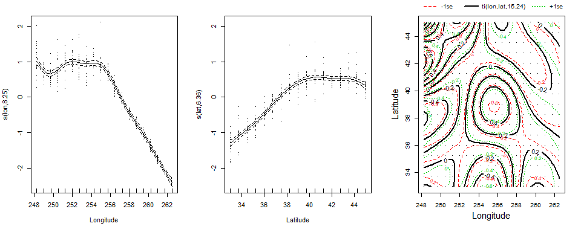

```r
plot.gam(gam.difs, select = 3, residuals = TRUE, xlab = 'Longitude', ylab = 'Latitude')

par(mfrow = c(2,2))
```

```
Method: REML   Optimizer: outer newton
full convergence after 7 iterations.
Gradient range [-2.969321e-06,2.271718e-06]
(score 56.11425 & scale 0.05742201).
Hessian positive definite, eigenvalue range [1.657357,168.2762].
Model rank =  35 / 35

Basis dimension (k) checking results. Low p-value (k-index<1) may
indicate that k is too low, especially if edf is close to k'.

               k'   edf k-index p-value
s(lon)       9.00  8.25    0.65  <2e-16 ***
s(lat)       9.00  6.36    0.64  <2e-16 ***
ti(lon,lat) 16.00 15.24    0.60  <2e-16 ***
---
Signif. codes:  0 ‘***’ 0.001 ‘**’ 0.01 ‘*’ 0.05 ‘.’ 0.1 ‘ ’ 1
```

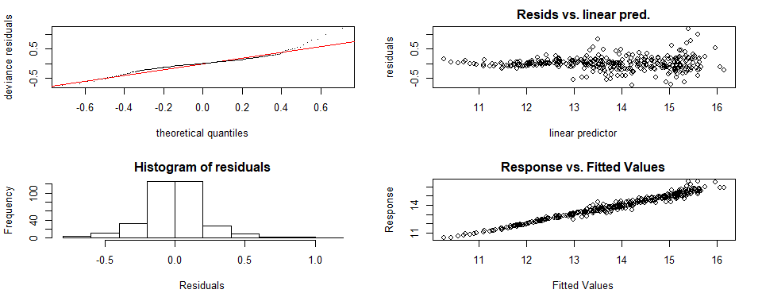

```r
gam.check(gam.difs)
```

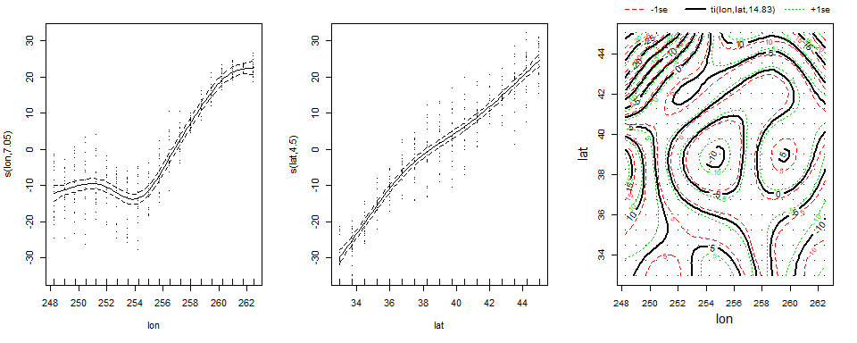

```r
par(mfrow = c(1,3))
plot(gam.vara, residuals = TRUE)

par(mfrow = c(2,2))
```

```
Method: REML   Optimizer: outer newton
full convergence after 6 iterations.
Gradient range [-3.017538e-07,2.059588e-07]
(score 1083.756 & scale 27.95131).
Hessian positive definite, eigenvalue range [1.408675,168.2183].
Model rank =  35 / 35

Basis dimension (k) checking results. Low p-value (k-index<1) may
indicate that k is too low, especially if edf is close to k'.

               k'   edf k-index p-value
s(lon)       9.00  7.05    0.29  <2e-16 ***
s(lat)       9.00  4.50    0.44  <2e-16 ***
ti(lon,lat) 16.00 14.83    0.35  <2e-16 ***
---
Signif. codes:  0 ‘***’ 0.001 ‘**’ 0.01 ‘*’ 0.05 ‘.’ 0.1 ‘ ’ 1
```

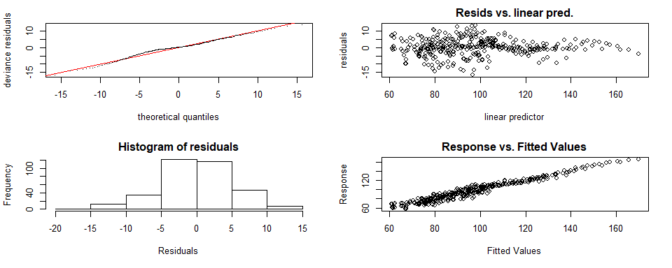

```r
gam.check(gam.vara)
```

Predict climate variables at the plot locations and append to the soil+forest data-frame:

```r
CO.TreeBinSoilClimate <- CO.TreeBinSoil %>%
  mutate(AVGT = predict(gam.avgt,
                        newdata = data.frame(lon = 360 + CO.TreeBinSoil$LON,
                                             lat = CO.TreeBinSoil$LAT)),
         JANT = predict(gam.jant,
                        newdata = data.frame(lon = 360 + CO.TreeBinSoil$LON,
                                             lat = CO.TreeBinSoil$LAT)),
         JULT = predict(gam.jult,
                        newdata = data.frame(lon = 360 + CO.TreeBinSoil$LON,
                                             lat = CO.TreeBinSoil$LAT)),
         PPT  = predict(gam.ppt,
                        newdata = data.frame(lon = 360 + CO.TreeBinSoil$LON,
                                             lat = CO.TreeBinSoil$LAT)),
         VARS = predict(gam.vars,
                        newdata = data.frame(lon = 360 + CO.TreeBinSoil$LON,
                                             lat = CO.TreeBinSoil$LAT)),
         VARW = predict(gam.varw,
                        newdata = data.frame(lon = 360 + CO.TreeBinSoil$LON,
                                             lat = CO.TreeBinSoil$LAT)),
         VARP = predict(gam.varp,
                        newdata = data.frame(lon = 360 + CO.TreeBinSoil$LON,
                                             lat = CO.TreeBinSoil$LAT)),
         VARA = predict(gam.vara,
                        newdata = data.frame(lon = 360 + CO.TreeBinSoil$LON,
                                             lat = CO.TreeBinSoil$LAT)),
         DIFS = predict(gam.difs,
                        newdata = data.frame(lon = 360 + CO.TreeBinSoil$LON,
                                             lat = CO.TreeBinSoil$LAT)),
         DIFW = predict(gam.difw,
                        newdata = data.frame(lon = 360 + CO.TreeBinSoil$LON,
                                             lat = CO.TreeBinSoil$LAT)),
         PPTS = predict(gam.ppts,
                        newdata = data.frame(lon = 360 + CO.TreeBinSoil$LON,
                                             lat = CO.TreeBinSoil$LAT)),
         PPTW  = predict(gam.pptw,
                        newdata = data.frame(lon = 360 + CO.TreeBinSoil$LON,
                                             lat = CO.TreeBinSoil$LAT)),
         VARP  = predict(gam.varp,
                        newdata = data.frame(lon = 360 + CO.TreeBinSoil$LON,
                                             lat = CO.TreeBinSoil$LAT)),
         )


summary(CO.TreeBinSoilClimate)
```

```
     PLT_CN               LAT             LON              ELEV          SPCD_202         SPCD_746          SPCD_122
 Min.   :3.642e+12   Min.   :36.99   Min.   :-109.1   Min.   : 4510   Min.   : 0.000   Min.   :  0.000   Min.   : 0.000
 1st Qu.:1.176e+13   1st Qu.:37.96   1st Qu.:-108.0   1st Qu.: 7320   1st Qu.: 0.000   1st Qu.:  0.000   1st Qu.: 0.000
 Median :3.727e+13   Median :38.88   Median :-106.9   Median : 8650   Median : 0.000   Median :  0.000   Median : 0.000
 Mean   :9.020e+13   Mean   :38.87   Mean   :-106.9   Mean   : 8592   Mean   : 1.861   Mean   :  4.789   Mean   : 1.296
 3rd Qu.:1.888e+14   3rd Qu.:39.74   3rd Qu.:-105.8   3rd Qu.: 9808   3rd Qu.: 0.000   3rd Qu.:  2.000   3rd Qu.: 0.000
 Max.   :4.319e+14   Max.   :41.00   Max.   :-103.0   Max.   :12800   Max.   :84.000   Max.   :126.000   Max.   :50.000
    SPCD_814         SPCD_19          SPCD_93         SPCD_65          SPCD_106         SPCD_108          SPCD_18
 Min.   :  0.00   Min.   : 0.000   Min.   :  0.0   Min.   : 0.000   Min.   : 0.000   Min.   :  0.000   Min.   : 0.0000
 1st Qu.:  0.00   1st Qu.: 0.000   1st Qu.:  0.0   1st Qu.: 0.000   1st Qu.: 0.000   1st Qu.:  0.000   1st Qu.: 0.0000
 Median :  0.00   Median : 0.000   Median :  0.0   Median : 0.000   Median : 0.000   Median :  0.000   Median : 0.0000
 Mean   :  2.94   Mean   : 2.552   Mean   :  4.8   Mean   : 2.335   Mean   : 2.219   Mean   :  3.569   Mean   : 0.3615
 3rd Qu.:  0.00   3rd Qu.: 0.000   3rd Qu.:  3.0   3rd Qu.: 0.000   3rd Qu.: 1.000   3rd Qu.:  0.000   3rd Qu.: 0.0000
 Max.   :104.00   Max.   :81.000   Max.   :123.0   Max.   :52.000   Max.   :56.000   Max.   :139.000   Max.   :43.0000
  SOIL_PLT_CN        FIELD_MOIST_SOIL_WT OVEN_DRY_SOIL_WT TOTAL_WATER_CONTENT_PCT  BULK_DENSITY      C_ORG_PCT        C_INORG_PCT
 Min.   :3.643e+12   Min.   :   3.47     Min.   :  3.36   Min.   :  1.058         Min.   :0.0240   Min.   : 0.3085   Min.   :0.0000
 1st Qu.:5.344e+12   1st Qu.: 174.54     1st Qu.:145.36   1st Qu.:  7.410         1st Qu.:0.3643   1st Qu.:11.3404   1st Qu.:0.0334
 Median :3.167e+13   Median : 263.60     Median :211.43   Median : 16.766         Median :0.5666   Median :19.4580   Median :0.0834
 Mean   :5.273e+13   Mean   : 325.31     Mean   :240.42   Mean   : 28.325         Mean   :0.6421   Mean   :18.7825   Mean   :0.1881
 3rd Qu.:3.727e+13   3rd Qu.: 388.81     3rd Qu.:305.59   3rd Qu.: 39.112         3rd Qu.:0.8016   3rd Qu.:25.4337   3rd Qu.:0.1402
 Max.   :1.888e+14   Max.   :1502.29     Max.   :867.07   Max.   :199.553         Max.   :3.1482   Max.   :47.2243   Max.   :4.3680
  C_TOTAL_PCT      N_TOTAL_PCT     TXTRLYR1 TXTRLYR2    FORFLTHK        LTRLRTHK          CONDID         DPTHSBSL
 Min.   : 0.546   Min.   :0.0305   3:1024   3:1089   Min.   :0.000   Min.   :0.0000   Min.   :1.000   Min.   : 0.000
 1st Qu.:11.524   1st Qu.:0.3907   1:4274   1:3252   1st Qu.:0.200   1st Qu.:0.1562   1st Qu.:1.000   1st Qu.: 2.000
 Median :19.649   Median :0.6290   2:1036   9: 571   Median :0.725   Median :0.4000   Median :1.000   Median : 4.400
 Mean   :18.971   Mean   :0.6070   9: 255   4: 241   Mean   :1.067   Mean   :0.5545   Mean   :1.055   Mean   : 5.597
 3rd Qu.:25.434   3rd Qu.:0.8168   0: 138   2:1700   3rd Qu.:1.675   3rd Qu.:0.8250   3rd Qu.:1.000   3rd Qu.: 7.500
 Max.   :47.224   Max.   :1.7413   4: 195   0:  69   Max.   :6.275   Max.   :2.3750   Max.   :3.000   Max.   :20.000
      AVGT            JANT            JULT            PPT             VARS             VARW            VARP
 Min.   :277.8   Min.   :267.5   Min.   :289.6   Min.   :22.67   Min.   : 6.504   Min.   :14.34   Min.   :1.127e-05
 1st Qu.:278.5   1st Qu.:268.2   1st Qu.:290.5   1st Qu.:27.93   1st Qu.: 7.455   1st Qu.:15.09   1st Qu.:1.718e-05
 Median :279.4   Median :269.0   Median :291.3   Median :29.67   Median : 8.284   Median :16.01   Median :1.938e-05
 Mean   :279.6   Mean   :269.2   Mean   :291.5   Mean   :29.34   Mean   : 8.410   Mean   :16.58   Mean   :1.993e-05
 3rd Qu.:280.3   3rd Qu.:270.0   3rd Qu.:292.4   3rd Qu.:30.99   3rd Qu.: 9.233   3rd Qu.:17.64   3rd Qu.:2.313e-05
 Max.   :286.8   Max.   :276.0   Max.   :298.2   Max.   :32.63   Max.   :11.730   Max.   :26.72   Max.   :2.723e-05
      VARA             DIFS            DIFW            PPTS            PPTW
 Min.   : 74.03   Min.   :13.95   Min.   :10.56   Min.   :3.889   Min.   :2.782
 1st Qu.: 77.29   1st Qu.:14.85   1st Qu.:12.18   1st Qu.:5.476   1st Qu.:5.164
 Median : 82.12   Median :15.11   Median :12.98   Median :6.582   Median :6.487
 Mean   : 82.85   Mean   :15.11   Mean   :13.09   Mean   :6.633   Mean   :6.142
 3rd Qu.: 87.42   3rd Qu.:15.37   3rd Qu.:14.02   3rd Qu.:7.803   3rd Qu.:7.174
 Max.   :100.62   Max.   :15.66   Max.   :15.13   Max.   :8.558   Max.   :7.984
```

Check temperature to make sure prediction was okay:

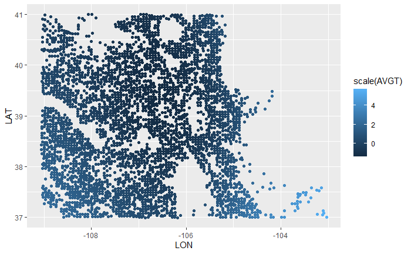

```r
ggplot(data = CO.TreeBinSoilClimate, aes(x = LON, y = LAT, color = scale(AVGT))) +
  geom_point()
```

Write to a a csv for later or new notebook

```r
#write.csv(CO.TreeBinSoilClimate, "ForestClimate.csv")
```

Create a table for making predictions:

We need to get elevation information, soil information, and climate information on a grid of longitude/latitude points.

Construct grid of Lat/Lon coordinates

```r
CO.plot.nona <- CO.plot %>% select(c(LON, LAT, ELEV))
CO.plot.nona <- CO.plot.nona[-which(is.na(CO.plot$ELEV)),]

lon.list <- seq(from = min(CO.plot.nona$LON),
                to = max(CO.plot.nona$LON),
                by = 0.01)
lat.list <- seq(from = min(CO.plot.nona$LAT),
                to = max(CO.plot.nona$LAT),
                by = 0.01)
coord.grid <- expand.grid(LON = lon.list, LAT = lat.list)
paste("coord grid size: ", dim(coord.grid))
```

```
[1] "coord grid size:  281502" "coord grid size:  2"
```

```r
head(coord.grid)
```

|  | LON | LAT |
| --- | --- | --- |
| 1 | -109.0587 | 36.99328 |
| 2 | -109.0487 | 36.99328 |
| 3 | -109.0387 | 36.99328 |
| 4 | -109.0287 | 36.99328 |
| 5 | -109.0187 | 36.99328 |
| 6 | -109.0087 | 36.99328 |

Use knn for nearest neighbor interpolation of elevation:

```r
elev.interp <- class::knn(CO.plot.nona %>% select(c(LON, LAT)),
                          coord.grid,
                          CO.plot.nona$ELEV,
                          k = 1)
coord.grid$ELEV <- as.numeric(as.character(elev.interp))
head(coord.grid)
```

|  | LON | LAT | ELEV |
| --- | --- | --- | --- |
| 1 | -109.0587 | 36.99328 | 4930 |
| 2 | -109.0487 | 36.99328 | 4930 |
| 3 | -109.0387 | 36.99328 | 4930 |
| 4 | -109.0287 | 36.99328 | 4930 |
| 5 | -109.0187 | 36.99328 | 4930 |
| 6 | -109.0087 | 36.99328 | 4930 |

Check with a visual raster plot of the data:

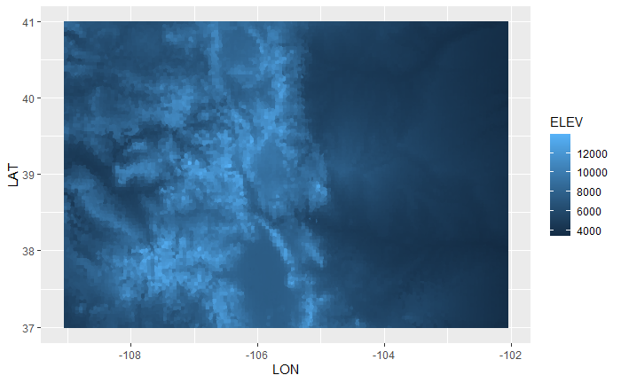

```r
ggplot(data = coord.grid, aes(x = LON, y = LAT, fill = ELEV)) +
  geom_raster(interpolate = TRUE)
```

Using knn to interpolate the soil data as was done before, lets do the same:

```r
## Create the model interpolation
soilGrid.interp <- class::knn(soil.coords,
                              coord.grid[,c(1,2)],
                              soil.cs)

## Get the corresponding plot number for each lat/lon
coord.grid <- coord.grid %>%
  mutate(SOIL_PLT_CN =
           as.numeric(as.character(soilGrid.interp)))

## Join soil table with coordinate table
coord.grid <- inner_join(coord.grid, soils.df, by = c("SOIL_PLT_CN" = "PLT_CN")) %>%
  select(-c(LON.y, LAT.y)) %>%
  rename(LON = LON.x, LAT = LAT.x)

head(coord.grid)
```

|  | LON | LAT | ELEV | SOIL_PLT_CN | FIELD_MOIST_SOIL_WT | OVEN_DRY_SOIL_WT | TOTAL_WATER_CONTENT_PCT | BULK_DENSITY | C_ORG_PCT | C_INORG_PCT | C_TOTAL_PCT | N_TOTAL_PCT | TXTRLYR1 | TXTRLYR2 | FORFLTHK | LTRLRTHK | CONDID | DPTHSBSL |
| --- | --- | --- | --- | --- | --- | --- | --- | --- | --- | --- | --- | --- | --- | --- | --- | --- | --- | --- |
| 1 | -109.0587 | 36.99328 | 4930 | 3.537414e+13 | 161.2225 | 153.275 | 3.1075 | 0.84075 | 15.462 | 0.17575 | 15.63775 | 0.2985 | 3 | 2 | 0.2 | 0.2 | 1 | 4.2 |
| 2 | -109.0487 | 36.99328 | 4930 | 3.537414e+13 | 161.2225 | 153.275 | 3.1075 | 0.84075 | 15.462 | 0.17575 | 15.63775 | 0.2985 | 3 | 2 | 0.2 | 0.2 | 1 | 4.2 |
| 3 | -109.0387 | 36.99328 | 4930 | 3.537414e+13 | 161.2225 | 153.275 | 3.1075 | 0.84075 | 15.462 | 0.17575 | 15.63775 | 0.2985 | 3 | 2 | 0.2 | 0.2 | 1 | 4.2 |
| 4 | -109.0287 | 36.99328 | 4930 | 3.537414e+13 | 161.2225 | 153.275 | 3.1075 | 0.84075 | 15.462 | 0.17575 | 15.63775 | 0.2985 | 3 | 2 | 0.2 | 0.2 | 1 | 4.2 |
| 5 | -109.0187 | 36.99328 | 4930 | 3.537414e+13 | 161.2225 | 153.275 | 3.1075 | 0.84075 | 15.462 | 0.17575 | 15.63775 | 0.2985 | 3 | 2 | 0.2 | 0.2 | 1 | 4.2 |
| 6 | -109.0087 | 36.99328 | 4930 | 3.537414e+13 | 161.2225 | 153.275 | 3.1075 | 0.84075 | 15.462 | 0.17575 | 15.63775 | 0.2985 | 3 | 2 | 0.2 | 0.2 | 1 | 4.2 |

Check with a visual raster plot of the data:

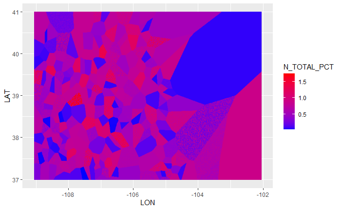

```r
ggplot(data = coord.grid, aes(x = LON, y = LAT, fill = N_TOTAL_PCT)) +
  geom_raster(interpolate = TRUE)+
  scale_fill_continuous(low = "blue", high = "red")
```

Using the existing GAM climate smooths, we predict at the grid of LAT/LON locations:

```r
coord.grid <- coord.grid %>%
  mutate(AVGT = predict(gam.avgt,
                        newdata = data.frame(lon = 360 + coord.grid$LON,
                                             lat = coord.grid$LAT)),
         JANT = predict(gam.jant,
                        newdata = data.frame(lon = 360 + coord.grid$LON,
                                             lat = coord.grid$LAT)),
         JULT = predict(gam.jult,
                        newdata = data.frame(lon = 360 + coord.grid$LON,
                                             lat = coord.grid$LAT)),
         PPT  = predict(gam.ppt,
                        newdata = data.frame(lon = 360 + coord.grid$LON,
                                             lat = coord.grid$LAT)),
         VARS = predict(gam.vars,
                        newdata = data.frame(lon = 360 + coord.grid$LON,
                                             lat = coord.grid$LAT)),
         VARW = predict(gam.varw,
                        newdata = data.frame(lon = 360 + coord.grid$LON,
                                             lat = coord.grid$LAT)),
         VARP = predict(gam.varp,
                       newdata = data.frame(lon = 360 + coord.grid$LON,
                                             lat = coord.grid$LAT)),
         VARA = predict(gam.vara,
                        newdata = data.frame(lon = 360 + coord.grid$LON,
                                             lat = coord.grid$LAT)),
         DIFS = predict(gam.difs,
                        newdata = data.frame(lon = 360 + coord.grid$LON,
                                             lat = coord.grid$LAT)),
         DIFW = predict(gam.difw,
                        newdata = data.frame(lon = 360 + coord.grid$LON,
                                             lat = coord.grid$LAT)),
         PPTS = predict(gam.ppts,
                        newdata = data.frame(lon = 360 + coord.grid$LON,
                                             lat = coord.grid$LAT)),
         PPTW  = predict(gam.pptw,
                        newdata = data.frame(lon = 360 + coord.grid$LON,
                                             lat = coord.grid$LAT)),
         VARP  = predict(gam.varp,
                        newdata = data.frame(lon = 360 + coord.grid$LON,
                                             lat = coord.grid$LAT)),
         )
summary(coord.grid)
```

```
      LON              LAT             ELEV        SOIL_PLT_CN        FIELD_MOIST_SOIL_WT OVEN_DRY_SOIL_WT TOTAL_WATER_CONTENT_PCT
 Min.   :-109.1   Min.   :36.99   Min.   : 3370   Min.   :3.643e+12   Min.   :   3.47     Min.   :  3.36   Min.   :  1.058
 1st Qu.:-107.3   1st Qu.:37.99   1st Qu.: 4880   1st Qu.:1.174e+13   1st Qu.: 203.14     1st Qu.:156.44   1st Qu.:  5.307
 Median :-105.6   Median :38.99   Median : 6510   Median :3.166e+13   Median : 290.22     Median :255.77   Median :  9.660
 Mean   :-105.6   Mean   :38.99   Mean   : 6849   Mean   :4.175e+13   Mean   : 342.05     Mean   :276.77   Mean   : 21.686
 3rd Qu.:-103.8   3rd Qu.:39.99   3rd Qu.: 8490   3rd Qu.:3.537e+13   3rd Qu.: 421.05     3rd Qu.:311.75   3rd Qu.: 27.350
 Max.   :-102.0   Max.   :40.99   Max.   :13930   Max.   :1.888e+14   Max.   :1502.29     Max.   :867.07   Max.   :199.553
  BULK_DENSITY      C_ORG_PCT        C_INORG_PCT      C_TOTAL_PCT      N_TOTAL_PCT     TXTRLYR1   TXTRLYR2      FORFLTHK
 Min.   :0.0240   Min.   : 0.3085   Min.   :0.0000   Min.   : 0.546   Min.   :0.0305   3: 99205   3: 76879   Min.   :0.000
 1st Qu.:0.3700   1st Qu.: 3.7740   1st Qu.:0.0325   1st Qu.: 4.121   1st Qu.:0.1650   1:142595   1:109776   1st Qu.:0.250
 Median :0.5944   Median :17.7957   Median :0.0950   Median :17.796   Median :0.5550   2: 28238   9: 44770   Median :1.150
 Mean   :0.7523   Mean   :15.3204   Mean   :0.2111   Mean   :15.532   Mean   :0.5310   9:  4944   4:  4732   Mean   :1.166
 3rd Qu.:1.0690   3rd Qu.:21.4328   3rd Qu.:0.3000   3rd Qu.:21.511   3rd Qu.:0.8086   0:  2546   2: 43867   3rd Qu.:1.950
 Max.   :3.1482   Max.   :47.2243   Max.   :4.3680   Max.   :47.224   Max.   :1.7413   4:  3974   0:  1478   Max.   :6.275
    LTRLRTHK          CONDID         DPTHSBSL           AVGT            JANT            JULT            PPT             VARS
 Min.   :0.0000   Min.   :1.000   Min.   : 0.000   Min.   :277.8   Min.   :267.5   Min.   :289.6   Min.   :21.65   Min.   : 6.503
 1st Qu.:0.1750   1st Qu.:1.000   1st Qu.: 1.800   1st Qu.:279.1   1st Qu.:268.7   1st Qu.:291.1   1st Qu.:25.58   1st Qu.: 7.978
 Median :0.6250   Median :1.000   Median : 2.800   Median :280.6   Median :270.4   Median :292.7   Median :28.02   Median : 9.323
 Mean   :0.7872   Mean   :1.077   Mean   : 4.963   Mean   :281.4   Mean   :270.9   Mean   :293.4   Mean   :27.73   Mean   : 9.532
 3rd Qu.:1.1500   3rd Qu.:1.000   3rd Qu.: 6.000   3rd Qu.:283.8   3rd Qu.:273.3   3rd Qu.:295.7   3rd Qu.:29.94   3rd Qu.:10.850
 Max.   :2.3750   Max.   :3.000   Max.   :20.000   Max.   :288.1   Max.   :276.7   Max.   :299.8   Max.   :32.63   Max.   :14.602
      VARW            VARP                VARA             DIFS            DIFW            PPTS            PPTW
 Min.   :14.34   Min.   :1.109e-05   Min.   : 73.96   Min.   :13.43   Min.   :10.53   Min.   :3.888   Min.   :2.651
 1st Qu.:15.62   1st Qu.:1.840e-05   1st Qu.: 79.88   1st Qu.:14.70   1st Qu.:12.46   1st Qu.:6.026   1st Qu.:3.054
 Median :18.60   Median :2.414e-05   Median : 86.49   Median :15.04   Median :13.47   Median :7.478   Median :4.643
 Mean   :20.34   Mean   :2.242e-05   Mean   : 87.31   Mean   :14.96   Mean   :13.37   Mean   :7.028   Mean   :4.883
 3rd Qu.:24.77   3rd Qu.:2.587e-05   3rd Qu.: 93.59   3rd Qu.:15.30   3rd Qu.:14.36   3rd Qu.:7.952   3rd Qu.:6.604
 Max.   :33.58   Max.   :3.092e-05   Max.   :110.37   Max.   :15.66   Max.   :15.14   Max.   :8.578   Max.   :7.985
```

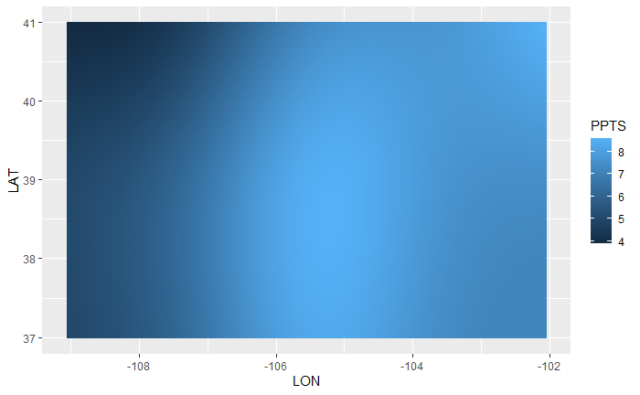

```r
ggplot(data = coord.grid, aes(x = LON, y = LAT, fill = PPTS)) +
  geom_raster(interpolate = TRUE)
```

Write the prediction grid to a csv file for later use:

```r
#write.csv(coord.grid, "prediction_grid.csv")
```